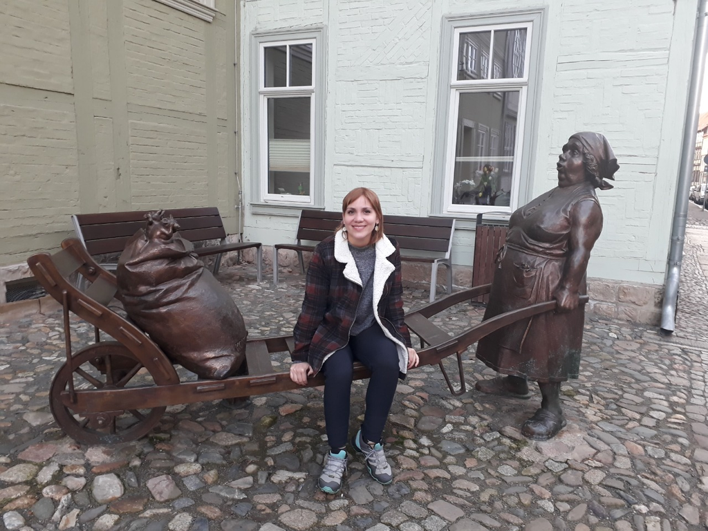

# Francesca Danae Rosales Rojas

## Perfil profesional

Cientista política con amplia experiencia en el procesamiento, análisis y reportería de información. Me interesan los cambios que se están produciendo en la era digital, tanto en las relaciones humanas como en las nuevas formas de productividad. Soy una profesional muy adaptable y abierta a los desafíos. Me interesa estar en espacios que me hacen sentido y no tengo miedo a los cambios. Estoy en constante formación, ya que el mundo avanza muy rápido y mi objetivo es siempre estar a la vanguardia. Mi meta es ser una nómada digital, aportar a la comprensión de las nuevas transformaciones y la adopción de tecnologías pertinentes a cada organización.

## Experiencia laboral

**EOL Research** | Jefa de Proyectos | Febrero 2022 - Present

**Fondo de Solidaridad e Inversión Social-FOSIS** | Analista de Estudios | Junio 2021 - Febrero 2022

**Ministerio de Vivienda y Urbanismo** | Analista Unidad de Control y Gestión | Reemplazo Enero 2021 - Junio 2021

**Universidad de Chile** | Coordinadora de Análisis de Datos y Analista de Observatorio de Género | Abril 2019 - Enero 2021

**Servicio Nacional de la Mujer y Equidad de Género** | Gestora de programas | Diciembre 2017 - Diciembre 2018

**Ministerio Secretaria General de la Presidencia** | Analista de Estudios | Enero 2016 - Diciembre 2018

## Educación

**Pontificia Universidad Católica de Chile**

Cientista Política | 2011 - 2015

**Universidad Diego Portales**

Magíster en Políticas Públicas | 2018-2020 *Beca Conicyt*

**Universidad Diego Portales**

Estudiante de Magíster en Pensamiento Contemporáneo | 2021-2022 *Beca Excelencia Académica IFF*

## Habilidades y conocimientos

*- Rstudio avanzado*

*- Manejo básico de SPSS y Python*

*- HTML5, CSS Y BOOTSTRAP*

*- Power bi*

*- Inglés B2 y Alemán básico*